# 의사결정나무 모델을 통해 알파벳 예측하기

```
목표 : 의사결정나무 모델중 RandomForest와 xgboost를 통해 알파벳을 예측
```

### 0. 데이터 및 라이브러리 불러오기

```r
library(caret)
```

```r
library(rpart)
library(rpart.plot)
library(randomForest)
library(xgboost)

letter <- read.csv("https://github.com/otzslayer/KHURStudy/raw/master/2016%20Big%20Leader%204th/Data/letter.csv")
head(letter)
```

```
##   letter xbox ybox width high onpix xbar ybar x2bar y2bar xybar x2ybr
## 1      T    2    8     3    5     1    8   13     0     6     6    10
## 2      I    5   12     3    7     2   10    5     5     4    13     3
## 3      D    4   11     6    8     6   10    6     2     6    10     3
## 4      N    7   11     6    6     3    5    9     4     6     4     4
## 5      G    2    1     3    1     1    8    6     6     6     6     5
## 6      S    4   11     5    8     3    8    8     6     9     5     6
##   xy2br xege xegvy yege yegvx
## 1     8    0     8    0     8
## 2     9    2     8    4    10
## 3     7    3     7    3     9
## 4    10    6    10    2     8
## 5     9    1     7    5    10
## 6     6    0     8    9     7
```

```r
set.seed(123)
trainIdx <- sort(sample(1:nrow(letter), size = 0.7 * nrow(letter)))
letterTrain <- letter[trainIdx, ]
letterTest <- letter[-trainIdx, ]
accuracy <- function(actual, predict){
  sum(actual == predict) / length(actual)
}
```

20000개의 데이터에서 70%를 트레인데이터로, 30%는 테스트 데이터로 활용하였다. 또한 0과 1의 케이스가 아닌 26개의 케이스의 정확도를 측정하는 것이므로 `confusionMatrix`보다는 `accuracy`값만 확인할 수 있도록 함수를 활용하였다.

### 1. CART알고리즘을 통한 기본모델

```r
## CART 알고리즘을 통한 기본 의사결정나무모델 만들기
letterTree = rpart(letter ~ ., data = letterTrain, method = "class")
predictLetter = predict(letterTree, letterTest, type = "class")

accuracy(letterTest$letter, predictLetter)
```

```
## [1] 0.485
```

`CART`알고리즘을 사용하여 의사결정모델을 만든 결과 48.5%가 나왔다. 정확도가 너무 낮기때문에 수업때 배운 `RandomForest`와 `xgboost`를 통해 모델을 개선해보기로 하였다.

### 2. RandomForest

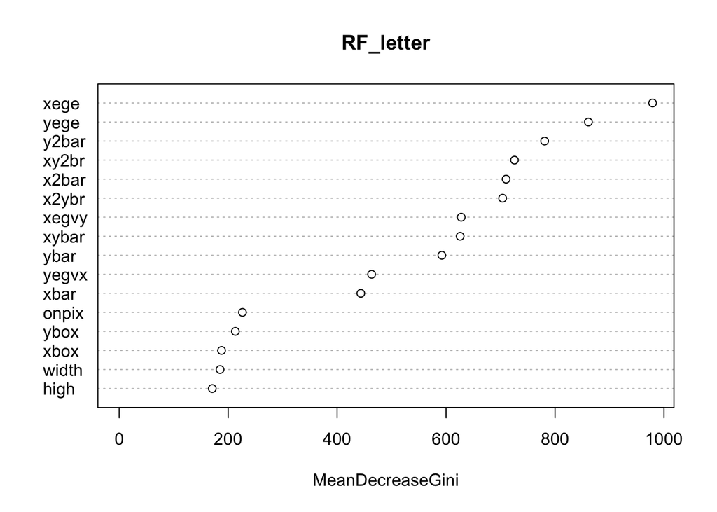

```r
## Randomforest를 통해 모델 일반화
RF_letter = randomForest(letter ~ ., data = letterTrain, ntree = 500, inportance = TRUE,
                         replace = FALSE, proximity = TRUE)
varImpPlot(RF_letter)
```

```r
pred_RF_letter = predict(RF_letter, letterTest)
accuracy(letterTest$letter, pred_RF_letter)
```

```
## [1] 0.961
```

### 3. Xgboost

좀 더 정교한 튜닝작업을 위해 `xgboost`를 사용하여 정확도를 더 올려보기로 하였다.

```r
trainLabel = as.numeric(letterTrain$letter) - 1
testLabel = as.numeric(letterTest$letter) - 1
trainMat = model.matrix( ~ ., data = letterTrain[ , -1])
testMat = model.matrix( ~ ., data = letterTest[ , -1])

letter_xgboost = xgboost(data = trainMat, label = trainLabel, max.depth = 9,
                         eta = 0.3, nrounds = 35, subsample = 1, num_class = 26, objective = "multi:softmax",
                         eval_metric = "merror")
xgboost_pred = predict(letter_xgboost, testMat)
accuracy(testLabel, xgboost_pred)
```

```
## [1] 0.955
```

`학습률`은 `0.3`에서 가장 높은 정확도를 보였다. +-0.01씩 조작해보았지만 과소적합, 과적합이 나타나는 것으로 보였다. `반복횟수`는 20부터 시작하여 계속 올려나갔으나 `35`에서 더 이상 정확도가 오르지 않는 모습을 확인할 수 있었다. `트리깊이`의 경우 위의 RandomForest 그래프에서 영향을 크게주는 요인이 상위 9개였기 때문에 9개로 깊이를 설정하니 정확도가 조금 상승하는 것을 확인할 수 있었다. 그 결과 **95.5%**의 정확도까지 끌어올렸으나, RandomForest의 결과를 능가할만한 모델을 찾지는 못했다.